# Exploring Red Wines by Andrew O’Gorman

### Alcohol/pH ratio

The plot below of alcohol levels vs pH shows a clear distinction between the quality scores of the red wines. It is apparent once again that in general a higher level of alcohol in the red wine is correlated with higher quality scores. It is interesting to note that as pH increases the alcohol level of the wine needs to increase to maintain the same level of quality score. This is despite only having a small correlation of 0.21 between alcohol and pH.

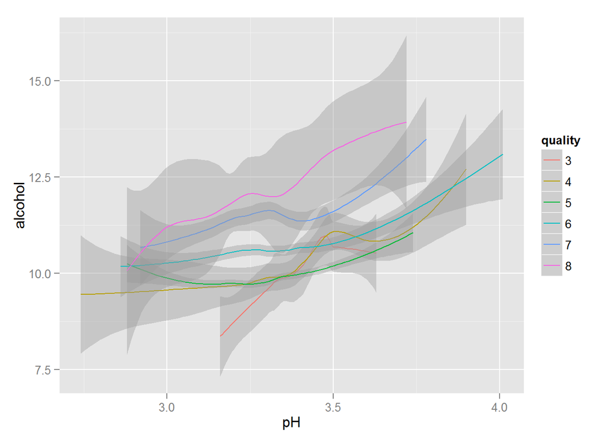

Looking further at this ratio of alcohol/pH you can see that it increases as the wine quality increases:

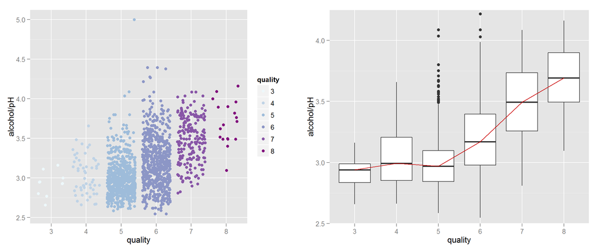

Due to the strong correlation between alcohol/pH and the quality of the wine we can look at the distribution of the quality of wines when comparing alcohol/pH and other variables.

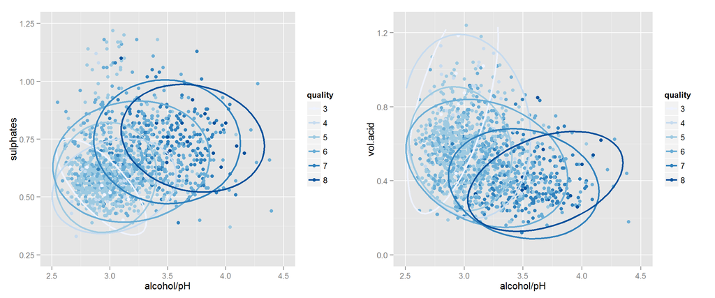

I used ellipses to show the 95% confidence range for each quality score. Here we can see that not only do we see a positive correlation between alcohol/pH and quality but also a positive correlation with sulphates too. However there is a clear negative correlation between volatile acidity and alcohol/pH, with the higher quality wines having a higher alcohol/pH level and a lower volatile acidity level.

### Exploring density further

We previously saw how there was a positive correlation (0.67) between density and fixed acidity levels in red wine. When overlaying the quality scores onto this chart we can see how for a given density, the higher quality wines have a higher level of fixed acidity.

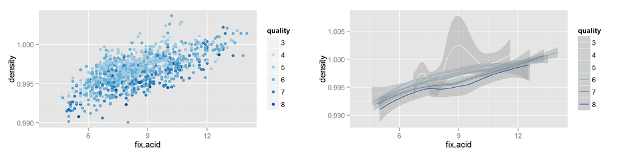

To explore the impact of acidity levels on wine quality scores I decided to look at the volatile acidity levels compared to density. Here we see that as volatile acidity increases the quality score decreases almost irrespective of the density level of the wine. The ellipses show the 75% confidence around each quality score. The chart shows that wine scoring 7 or 8 generally have a volatile acidity between 0.25 and 0.5 g/dm^3.

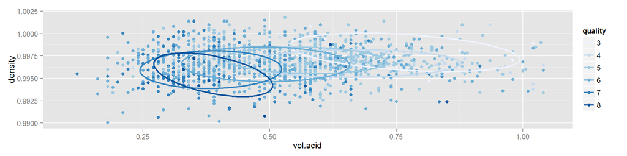

### pH Grouping

Finally I wanted to see for a given pH level how acidity affected the quality score of the wine. We saw earlier the relationships between citric acid/volatile acid/fixed acid and pH level, by grouping the pH levels I can overlay the quality score of each wine:

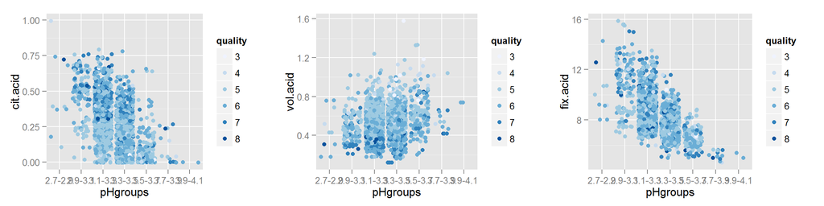

The plots show how for a given pH level higher quality wine has high citric acid levels and low volatile acidity levels. There doesn’t appear to be an obvious equivalent correlation between quality and fixed acidity (correltion score of 0.12) given a certain pH level.

# Multivariate Analysis

### Talk about some of the relationships you observed in this part of the investigation. Were there features that strengthened each other in terms of looking at your feature(s) of interest?

The multivariate plots reinforced the fact that alcohol level has the strongest correlation with the red wine quality score. I found there was an interesting correlation between pH levels and alcohol levels when looking at the wine quality. By plotting the ratio of alcohol/pH I was able to see how these combined varibales affected the quality of the wine. When comparing this ratio against other variables it was clear that higher quality wines had a high alcohol/pH ratio and higher levels of sulphates and lower levels of volatile acidity.

The first set of multivariate plots were really helpful in assessing the importance of some of the other important variables outside of alcohol on the quality score. Here I saw how alcohol levels need to be higher in low density wines to score high, whereas a higher density can have a lower alcohol level and still get a high quality score. Also how most of the high scoring wines had a volatile acidity level of between 0.3 and 0.5.

For a given pH level higher quality wine has high citric acid levels and low volatile acidity levels.

### Were there any interesting or surprising interactions between features?

I was surprised that when comparing alcohol/pH to quality scores that the median value for wines scoring 5 was lower than I expected. This and the interquartile range was smaller than expected. There are more wines scoring 5 in the dataset than any other score so this could possibly be explained by the fact it is an ‘average’ quality score and so many wines get put into this category than either high or low scoring categories.

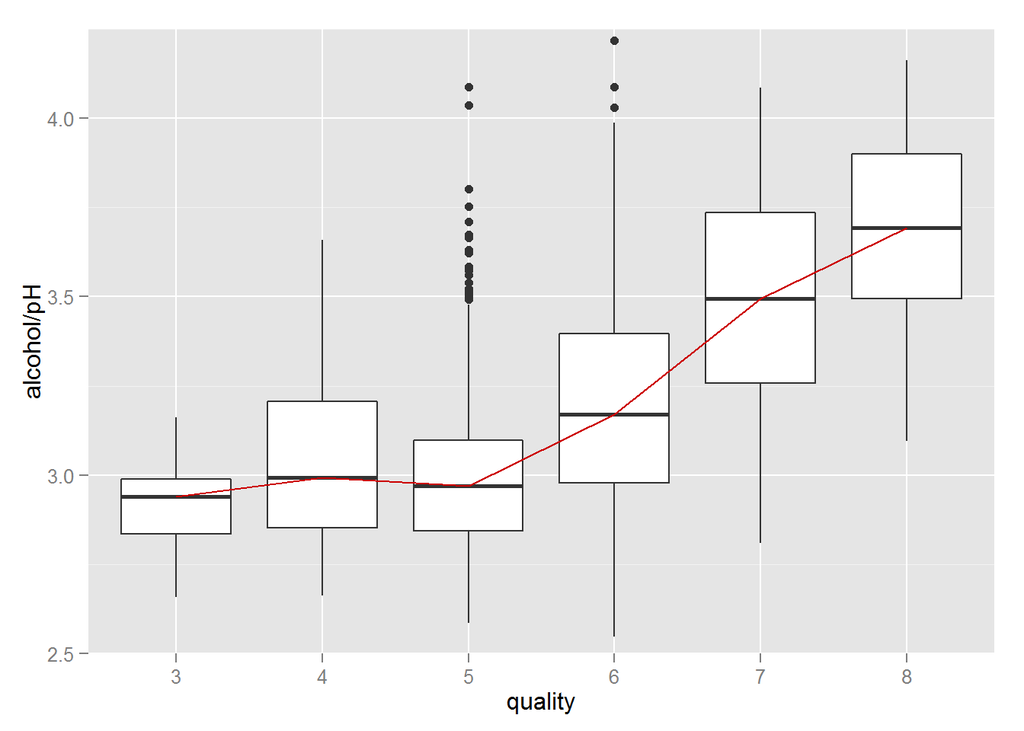

### OPTIONAL: Did you create any models with your dataset? Discuss the strengths and limitations of your model.

I was able to use the above analysis to help build a model to help predict the quality score of a red wine. I first used a variety of variables but then reduced it down to the following five after looking at how much impact they had on the final prediction. The variables I used were:

- Alcohol level
- Sulphate level
- Volatile acidity
- Chloride level
- pH level

```
##
## Calls:
## m1: lm(formula = I(as.numeric(quality)) ~ I(alcohol), data = redwine)
## m2: lm(formula = I(as.numeric(quality)) ~ I(alcohol) + sulphates,
##     data = redwine)
## m3: lm(formula = I(as.numeric(quality)) ~ I(alcohol) + sulphates +
##     vol.acid, data = redwine)
## m4: lm(formula = I(as.numeric(quality)) ~ I(alcohol) + sulphates +
##     vol.acid + chlorides, data = redwine)
## m5: lm(formula = I(as.numeric(quality)) ~ I(alcohol) + sulphates +
##     vol.acid + chlorides + pH, data = redwine)
##
## =================================================================
##                    m1        m2        m3        m4        m5
## -----------------------------------------------------------------
## (Intercept)     -0.125    -0.625***  0.611**   0.777***  2.009***
##                 (0.175)   (0.177)   (0.196)   (0.199)   (0.397)
## I(alcohol)       0.361***  0.346***  0.309***  0.292***  0.305***
##                 (0.017)   (0.016)   (0.016)   (0.016)   (0.017)
## sulphates                  0.994***  0.679***  0.874***  0.847***
##                           (0.102)   (0.101)   (0.111)   (0.110)
## vol.acid                            -1.221*** -1.167*** -1.069***
##                                     (0.097)   (0.097)   (0.101)
## chlorides                                     -1.645*** -1.929***
##                                               (0.394)   (0.400)
## pH                                                      -0.417***
##                                                         (0.117)
## -----------------------------------------------------------------
## R-squared           0.227     0.270     0.336     0.343     0.348
## adj. R-squared      0.226     0.269     0.335     0.341     0.346
## sigma               0.710     0.690     0.659     0.655     0.653
## F                 468.267   294.988   268.912   208.125   170.286
## p                   0.000     0.000     0.000     0.000     0.000
## Log-likelihood  -1721.057 -1675.142 -1599.384 -1590.682 -1584.294
## Deviance          805.870   760.894   692.105   684.612   679.164
## AIC              3448.114  3358.284  3208.768  3193.364  3182.589
## BIC              3464.245  3379.793  3235.654  3225.626  3220.229
## N                1599      1599      1599      1599      1599
## =================================================================
```

The variables in this linear model can account for only 34.8% of the variance in the quality of red wines. This is quite a weak prediction model and could be due to the fact that the wine score is limited to 11 values (0-10) and so linear regression might not be the best tool for modelling this type of data.

# Final Plots and Summary

### Plot One

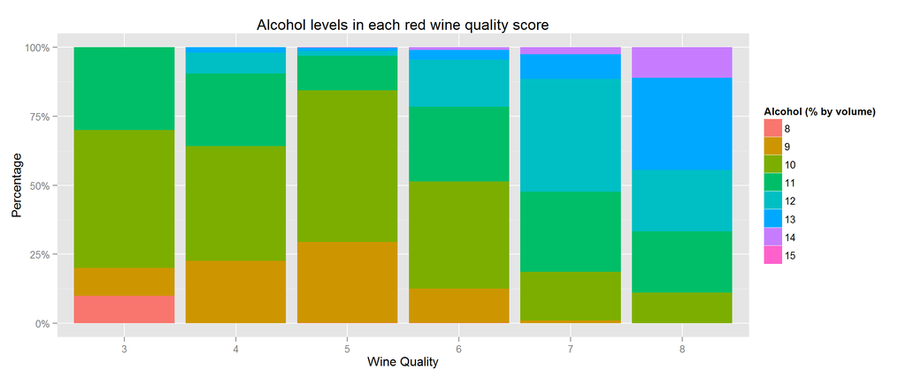

### Description One

My analysis of the factors determining the quality of a red wine showed that alcohol had the strongest correlation of the factors available with a score of 0.48. This plot clearly shows the alcohol level by percentage of wines at a given quality score. We can see from this chart how as the wine quality increases the alcohol percentage generally increases. There are fewer wines with a high quality score yet they generally have a higher alcohol content than low or medium scoring wines. Wines scoring an 8 out of 10 (the highest score in the data set) have the largest percentage of 14% and 13% alcohol levels. There are no wines with an alcohol level less than 10% scoring above a 7 out of 10. Wines with an alcohol level of 8% didn’t score higher than a 3 out of 10.

### Plot Two

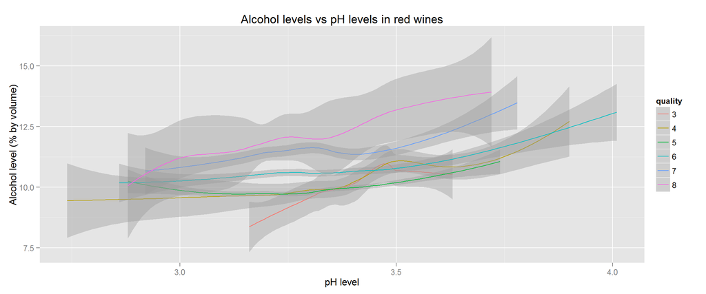

### Description Two

I chose this chart as it clearly shows the relationship between pH levels, alcohol levels and quality score in red wines. As the pH level increases, the alcohol percentage required for a given quality score increases. We can see the layering on this chart between the different quality scores with the higher scoring wines at the top and the lower scoring wines at the bottom.

### Plot Three

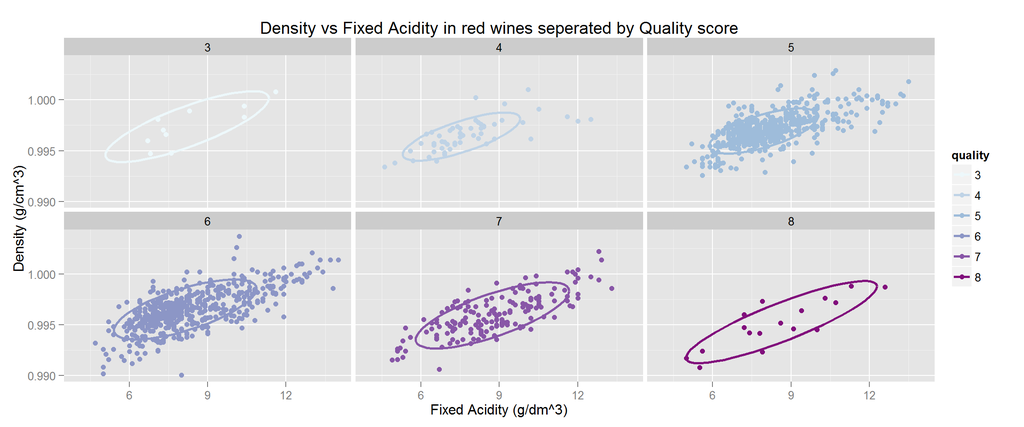

### Description Three

I chose this chart as it shows how both density and fixed acidity affect the quality score of a wine. Earlier in my analysis I showed using two multivariate plots the layering affect evident in wines of different qualities when comparing density vs ixed acidity. For this final plot I have faceted on quality to show this is relationship more clearly. The chart shows us three things, firstly that as the quality score increases the fixed acidity level for a given density increases. This can likely be explained by the relationship we observed between higher alcohol levels in higher scoring wines and how alcohol affects the density of a wine. Secondly we can see from the ellipses which represent the 80% confidence levels how the variance of the points increases in both high scoring and low scoring wines. This may well be because we have fewer wines at either end of the quality scale but would be something worth looking at further. Finally, this plot shows how fixed acidity and density have a strong positive correlation which matches the scoring of 0.67 we observed in the earier correlation matrix.

# Reflection

The red wine dataset contains data for 1599 red wines from 2009. All wines are from of the Portuguese “Vinho Verde” wine and the quality scores are the median values of three wine experts assessment of each wine. I spent a long time analysing the individual variables within the dataset and how each one affects the quality of the red wine. I found that the data was limited in how well it could be used to predict the quality of the wine, with more data available I would have been able to produce a much better model as there were many key features that were missing from this dataset, including:

- Year/Age
- Type of Grape
- Origin (include wines from different regions)
- Producer
- Official wine quality ratings (taking the median of many more experts to reduce the possibility of subjective bias)

However I was still able to extract interesting feactures and trends from this data including how the alcohol level was strongly correlated with the quality of the red wine. Also how the the alcohol level needs to change depending on the pH level to maintain a given quality score.

The data can only highlight correlations between variables and output but doesn’t look into the causality of the output. This is a key distinction as while many variables can be correlated, only some will cause a change in the other (e.g. acidity levels and overall pH). Knowing what causes the change in quality scoring is something that would require further analysis with a much larger dataset.

I believe the above analysis could go someway to helping winemakers focus on producing better (high quality scoring) wines by avoiding some of the feactures that appear to negatively affect the overall score like volatile acidity and focusing on some of the features associated with higher quality wines like alcohol and sulphate levels.